# Monitorización nivel de “salud” de una red corporativa de PC’s

Juan Carlos López, Fco. Javier Motos, Alonso Flores y David Martín

Junio 2017

##### Objetivo de la práctica

La práctica consiste en obtener el nivel de salud del parque de PCs en una empresa en función de las vulnerabilidades que tienen.

##### Condiciones:

Teniendo en cuenta que el CVSS se basa en la combinación de tres métricas, la presente práctica parte del valor BASE asignado a cada vulnerabilidad en su publicación. Este valor se ve modificado por factores TEMPORALES y de ENTORNO. En nuestro caso solo hemos considerado 2 de ellos: **el base y el de entorno.**

##### Criterio de referencia

El criterio utilizado se basa en el CVSS - Common Vulnerability Scoring System v3.0. Creado en 2004, se ha convertido en un standard. CVSS es un entorno de trabajo diseñado para comunicar las características y la severidad de las vulnerabilidades de software.

*CVSS - Common Vulnerability Scoring System v3.0*

**3 Importantes beneficios**

1. Proporciona puntuaciones de vulnerabilidad estandarizadas. Cuando una organización utiliza un algoritmo para anotar vulnerabilidades en todas las plataformas de TI, puede definir una política de gestión de vulnerabilidades que define el tiempo máximo permitido para validar y remediar una vulnerabilidad dada.
2. Provee un marco abierto. Los usuarios pueden confundirse cuando se asigna una vulnerabilidad una puntuación arbitraria por un tercero. Con CVSS, las características individuales derivan una puntuación transparente.
3. CVSS ayuda a priorizar el riesgo. Cuando se calcula la puntuación de entorno, la vulnerabilidad se convierte en contextual para cada organización, y ayuda a proporcionar una mejor comprensión del riesgo que representa una vulnerabilidad para la organización.

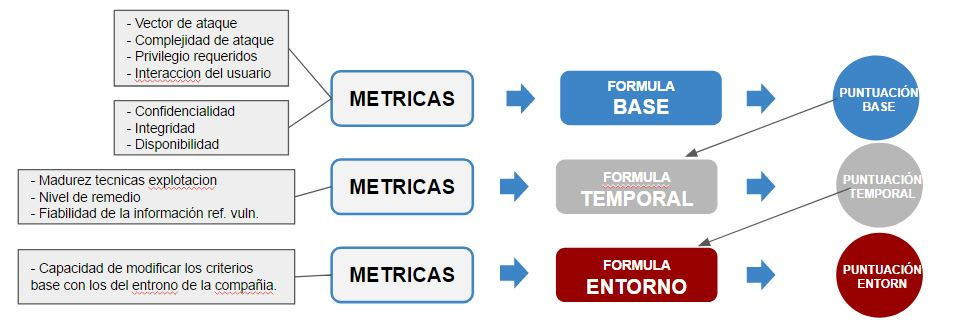

Criterios CVSS

Teniendo en cuenta que el CVSS se basa en la combinación de tres métricas, la presente práctica parte del valor BASE asignado a cada vulnerabilidad en su publicación. Este valor se ve modificado por factores TEMPORALES y de ENTORNO. En nuestro caso solo hemos considerado 2 de ellos, el base y el de entorno.

### Preguntas a responder

La salud de parque la determinamos a partir de una serie de gráficos que presentan la distribución de las vulnerabilidades y criticidades en el parque de la empresa:

- Distribución del nº de vulnerabilidades por valor CVSS
- Distribución del nº de vulnerabilidades por valor nivel criticidad
- Mapa de dispersión vulnerabilidades parque cliente
- Mapa distribución vulnerabilidades por valor escala de criticidad

#### El flujo planteado es:

- Obtener el software instalado de las máquinas de la empresa (Se identifican: nombre del software, versión, fabricante y nombre del computador)

```
##                     name    version       vendor  computer
## 9701 FLIR Device Drivers    1.4.0.0 FLIR Systems 00043.csv
## 9702 FLIR Device Drivers    1.4.0.0 FLIR Systems 00005.csv
## 9703        A360 Desktop 6.0.3.1100     Autodesk 00128.csv
## 9704  MATLAB Runtime 8.5        8.5    MathWorks 00036.csv
## 9705 Java(TM) 7 Update 2     7.0.20       Oracle 00184.csv
```

- Obtención del listado de CPEs oficiales de dichos programas, como por ejemplo:

```
## [1] "cpe:2.3:a:adobe:acrobat_reader:9.3:*:*:*:*:*:*:*"
## [2] "Adobe Acrobat Reader 9.3"
## [3] "acrobat_reader"
```

- Se realiza un matching entre CPEs y listado de software por cada máquina, para lo cual se utiliza el coeficiente de Jaccard para medir el grado de similitud entre CPE’s y softwares.

```
##                                name                                  cpe
## 1                 2N® Helios IP Eye               cpe:a:avaya:ip_agent:-
## 2 32 bit Windows Card Reader Driver cpe:a:foxitsoftware:reader:7.3.0.118
## 3           4K Video Downloader 3.8                              cpe::::
## 4                 7-Zip 16.04 (x64)               cpe:a:7-zip:7-zip:4.65
## 5                        7-Zip 9.20               cpe:a:7-zip:7-zip:9.20
```

- Obtenemos un listado de CVEs actualizados

```
## [1] "CVE-2009-3953"
## [2] "The U3D implementation in Adobe Reader and Acrobat 9.x before 9.3, 8.x before 8.2 on Windows and Mac OS X, and 7.x before 7.1.4 allows remote attackers to execute arbitrary code via malformed U3D data in a PDF document, related to a CLODProgressiveMeshDeclaration \"array boundary issue,\" a …
```

- Se realiza un matching entre CVE y los CPE encontrados en el listado de software de cada máquina

```
##                 name      version      vendor  computer           cve cvss
## 147533 Google Chrome 26.0.1410.43 Google Inc. 00217.csv CVE-2011-3883  7.5
## 147534 Google Chrome 26.0.1410.43 Google Inc. 00217.csv CVE-2011-3884  6.8
## 147535 Google Chrome 26.0.1410.43 Google Inc. 00217.csv CVE-2011-3885  7.5
## 147536 Google Chrome 26.0.1410.43 Google Inc. 00217.csv CVE-2011-3887  5.0
## 147537 Google Chrome 26.0.1410.43 Google Inc. 00217.csv CVE-2011-3888  6.8
```

- Se establece un sistema de scoring de vulnerabilidades basado en el CVSS y se asigna un valor de “salud” por cada máquina.

```
##                               name  computer           cve         nivel
## 1      Windows Internet Explorer 8 00000.csv CVE-2009-1043 NIVEL_CRITICO
## 2   Microsoft .NET Framework 4.5.1 00001.csv CVE-2014-1806 NIVEL_CRITICO
## 3      Windows Internet Explorer 8 00002.csv CVE-2009-1043 NIVEL_CRITICO
## 4  Microsoft SQL Server VSS Writer 00003.csv CVE-2002-0721 NIVEL_CRITICO
## 5      Windows Internet Explorer 8 00004.csv CVE-2009-1043 NIVEL_CRITICO
## 6      Windows Internet Explorer 8 00005.csv CVE-2009-1043 NIVEL_CRITICO
## 7      Windows Internet Explorer 8 00006.csv CVE-2009-1043 NIVEL_CRITICO
## 8       Kensington Display Adapter 00007.csv          <NA> NO_VULNERABLE
## 9                 Application Name 00008.csv          <NA> NO_VULNERABLE
## 10                   Google Chrome 00009.csv CVE-2010-1230 NIVEL_CRITICO
```

- Se visualiza los resultados desde diferentes perspectivas

#### NOTA: Para garantizar la presentación de resultados se ha desarrollado un módulo específico para la creación de un entorno simulado partiendo de las siguientes condiciones:

- Fichero con el listado de los programas comprados por la empresa
- Fichero con los PC’s instalados en la empresa y su criticidad
- Creación de un fichero de vulnerabilidades por software (número aleatorio de vulnerabilidades y también severidad aleatoria)
- Creación de un entorno ficción en el que cada pc tiene un número aleatorio de programas instalados, a partir del cual se genera el fichero final con la relación de software y vulnerabilidades instaladas por pc en la compañía

##### Condiciones de dicha función:

- 100 pc’s
- 23 programas corporativos
- n vulnerabilidades

#### *Fuente de datos*

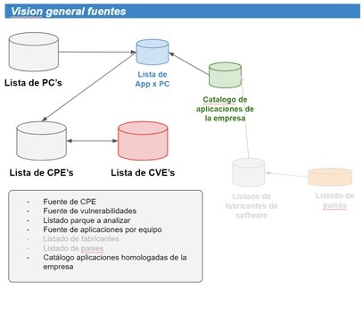

Fuente de datos

#### *Algoritmo y funciones*

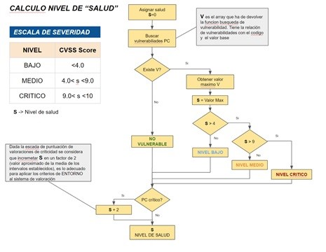

Algoritmo y funciones

## **Resultados (Modelo Real)**

## GRAFICO 1 - Distribución de vulnerabilidades por valor CVSS

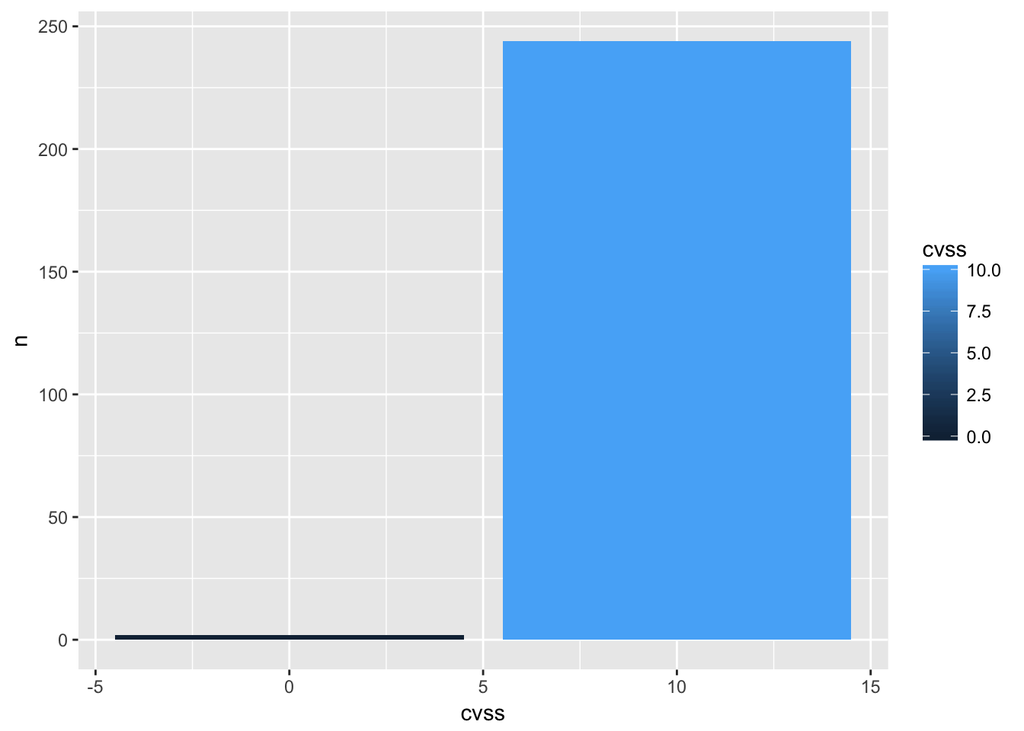

## GRAFICO 2 - Distribución de vulnerabilidades por nivel de criticidad CVSS

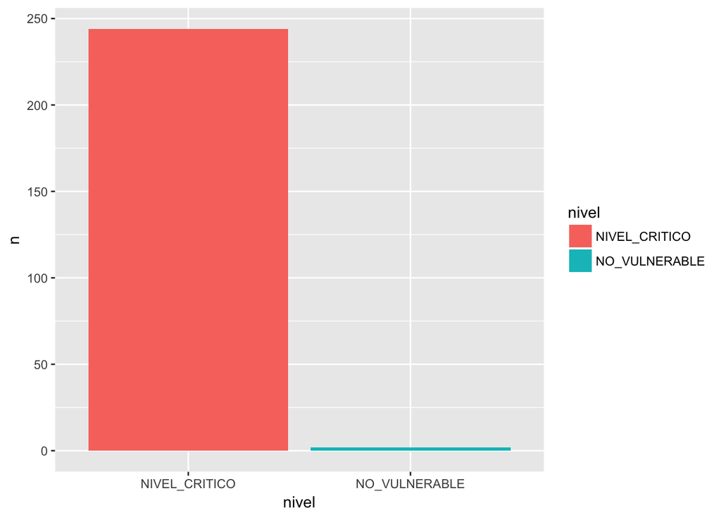

## GRAFICO 3 - Mapa dispersión vulnerabilidades parque cliente

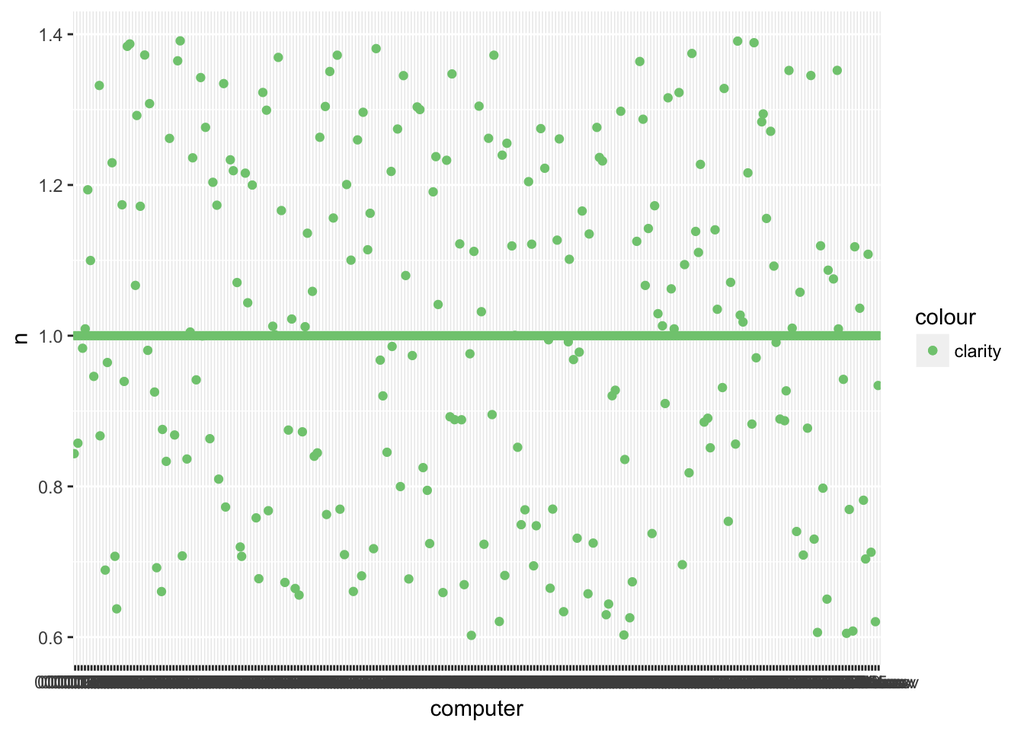

## GRAFICO 4 - Mapa distribución vulnerabilidades por valor escala de criticidad

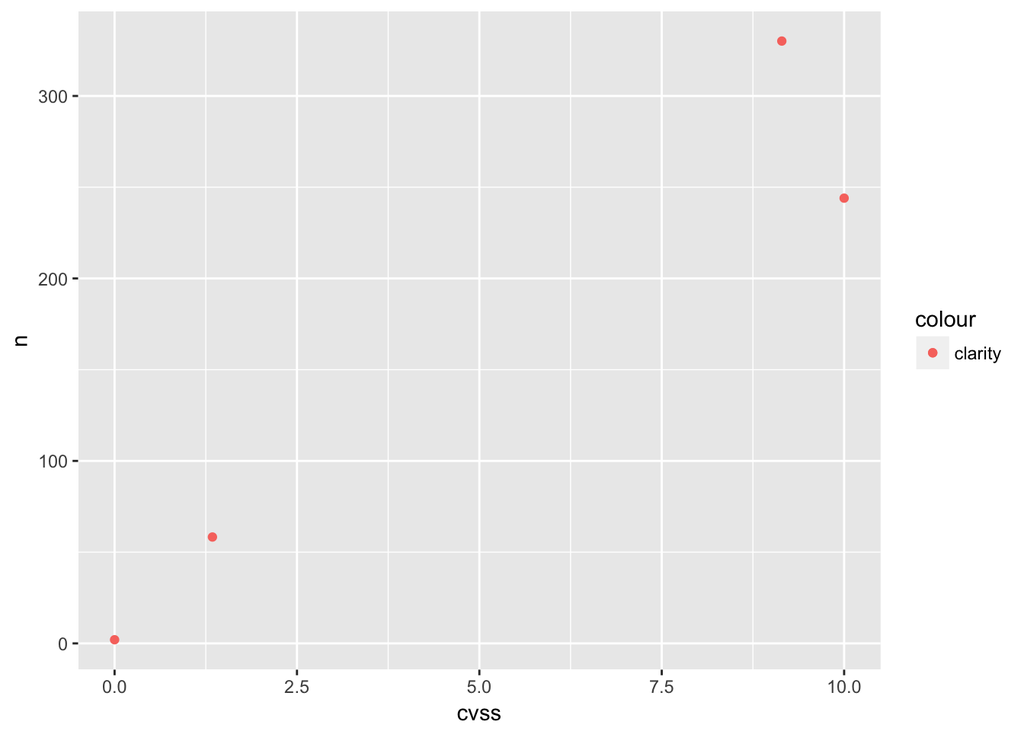

## **Resultados (Modelo Simulado)**

## GRAFICO 1 - Distribución de vulnerabilidades por valor CVSS

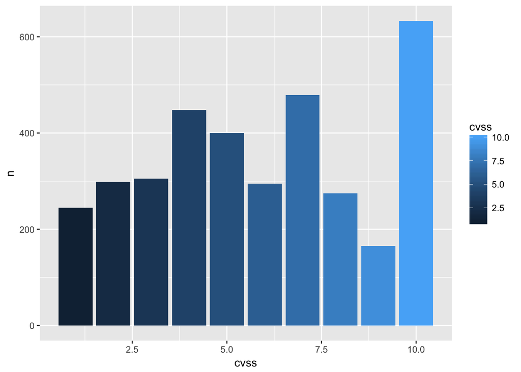

## GRAFICO 2 - Distribución de vulnerabilidades por nivel de criticidad CVSS

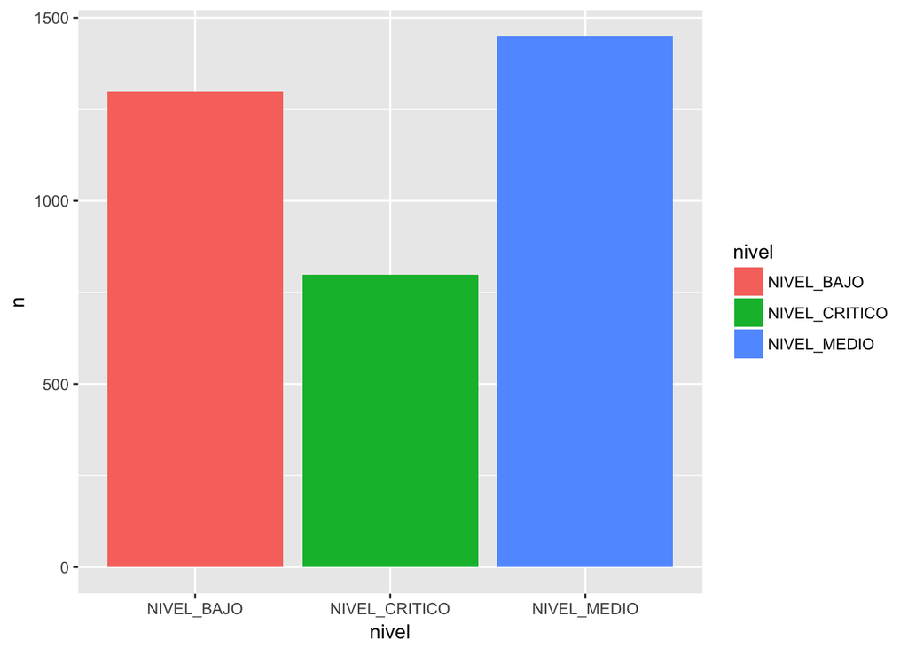

## GRAFICO 3 - Mapa dispersión vulnerabilidades parque cliente

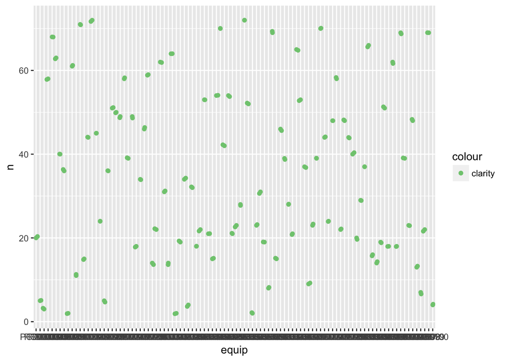

## GRAFICO 4 - Mapa distribución vulnerabilidades por valor escala de criticidad

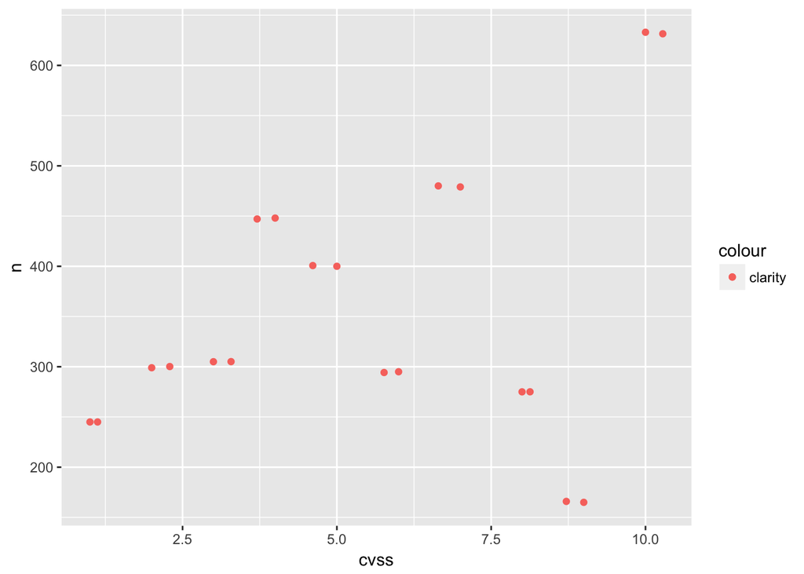

## Conclusión

Completada la práctica podemos concluir al respecto que:

- El intento de crear un entorno real de instalación de software en una empresa y el análisis de sus vulnerabilidades nos lleva a una situación “singular”, porque? La aplicación del criterio de mínimos para preservar una empresa de posibles ataques hace que el nivel de riesgo del parque instalado esté definido por el valor máximo de la unidad mínima de riesgo (una vulnerabilidad de cualquier programa). Así delante de esta situación con mucha facilidad el nivel de riego de nuestro parque está en la zona alta.
- Si tomamos un punto de vista exclusivamente estadístico (fuera de la realidad), la función de scoring creada debería de revisarse para conseguir una mayor dispersión.

Delante de esta situación hemos jugado con los datos para cumplir con los requerimientos de la práctica, es decir, obtención de datos origen en fuentes reales, programación del matching de los datos y revisión de las opciones de presentación de datos.

## ===================================================